```python
#!pip install reverse_geocoder
#!pip install DateTime
#!%conda install dask
```

# Exploratory Analysis

1. What are busiest locations and hours?
2. How are passengers per trip, payment type, fare and tip amounts distributed?
3. How do times and fares vary by trips?
4. Is it possible to characterise taxi drivers based on work hours and how much they make? # Open Questions
5. What features influence fare and tip amounts?
6. Can we build a model to predict fare and tip amount?
7. If you were a taxi owner, how would you maximize your earnings in a day?

# The data: NYC taxi data January 2013

**Describe the Variables**

- medallion : from wikipedia: A taxi medallion, also known as a CPNC (Certificate of Public Necessity and Convenience), is a transferable permit...cities in the US use these in their taxi licensing systems
- hack licence : To operate a vehicle as a yellow cab, you must complete the TLC hack-up certification and inspection. (nyc1.gov)
- vendor_id : the LPEP provider
- rate_code :
- store_and_fwd_flag : indicates if the driver had no internet at the time and hada to forward the data later (flag indicates penalty for this)
- pickup and drop off
- passenger count
- trip_time_in_secs
- trip_distance in km
- MTA tax is .50 imposed by NYC paid by passenger (dropping from future analysis) MTA Tax. The “MTA Tax” is the 50-cent tax on taxicab trips that is imposed by article 29-A of the New York State Tax Law.
- Vendor ID - code indicating the TPEP provider - dropping

```python
import reverse_geocoder as rg
import pandas as pd
import numpy as np
import json
import requests
import folium
import geopy
import seaborn as sns
#import matplotlib as plt
import matplotlib.pyplot as plt
import plotly.express as px
import plotly.graph_objects as go
```

**Introduction**

The urls for the data sets were given as: https://archive.org/download/nycTaxiTripData2013/trip_data.7z https://archive.org/download/nycTaxiTripData2013/trip_fare.7z

Trip and fare data were obtained by visiting the location where the .7z files are hosted: https://archive.org/download/nycTaxiTripData2013

The individual data files for each month were available for download at this location.

**Load January Trip Data**

```python
#january trip data

#jtd = '/Users/gretastojanovic/Desktop/DS/data/trip_data_1.csv'
jtd = 'trip_data_1.csv'
list_of_chunks = []
def get_data(chunk):
     for chunk in pd.read_csv(chunk, chunksize = 500000):
        list_of_chunks.append(chunk)
#get_data(jtd)
#print('get_data done')
```

The below code was used to import the entire january trip data file. The code is commented out as once processed, the dataframe was exported to a csv and will be reimported below to reduce processing time.

```python
#all_chunks = pd.concat(list_of_chunks, axis=0, ignore_index=False)
#ac = pd.DataFrame(all_chunks)
print('done')
```

```
done
```

```python
def get_date_time_formats(df):
    df['pickup_datetime'] = [pd.Timestamp(d) for d in df['pickup_datetime']]
    df['p_date'] = [d.date() for d in df['pickup_datetime']]
    df['p_day_name'] = [d.day_name() for d in df['pickup_datetime']]
    df['p_hour'] = [d.hour for d in df['pickup_datetime']]

#get_date_time_formats(ac)
print('get_date_time done')
```

```
get_date_time done
```

```python
#ac.dropna(inplace = True)
```

```python
def get_neighborhoods(df):
    coords1_df= list(zip(df['pickup_latitude'],df['pickup_longitude']))
    df['p_nhood'] = [d['name'] for d in rg.search(coords1_df)]
    coords2_df = list(zip(df['dropoff_latitude'], df['dropoff_longitude']))
    df['d_nhood'] =[d['name'] for d in rg.search(coords2_df)]

#get_neighborhoods(ac)
#print('neighborhoods done')
```

```python
# ac['counter'] = 1
# cols = ['counter', 'hack_license', 'p_nhood' ,'p_date', 'p_hour', 'p_day_name',
#         'pickup_datetime',
#        'rate_code', 'passenger_count',
#        'trip_time_in_secs', 'trip_distance', 'medallion', 'd_nhood']
# ac = ac[cols]
# ac.to_pickle('/Users/gretastojanovic/Documents/DataScience/Elula_Job_Pres_Prep/ac.pickle')
```

```python
# ac = '/Users/gretastojanovic/Documents/DataScience/Elula_Job_Pres_Prep/ac.pickle'
# ac = pd.read_pickle(ac)
```

**Load the January Fare Data**

```python
# fd = '/Users/gretastojanovic/Documents/DataScience/Elula_Job_Pres_Prep/trip_fare_1.csv'
# list_of_chunks = []
# def get_data(chunk):
#     for chunk in pd.read_csv(fd, chunksize = 1000000):
#         list_of_chunks.append(chunk)
# get_data(fd)
# print('get_data done')
# all_chunksf = pd.concat(list_of_chunks, axis=0, ignore_index=False)
# fdf = pd.DataFrame(all_chunksf)
# print('dataframe created')
# fdf = fdf.drop([' vendor_id', ' mta_tax', 'medallion'], axis = 1)
# print('columns dropped')
# fdf['pickup_datetime_f'] = [pd.Timestamp(d) for d in fdf[' pickup_datetime']]
# print('datetime converted')
# fdf.to_pickle('/Users/gretastojanovic/Documents/DataScience/Elula_Job_Pres_Prep/fdf.pickle')
```

```python
# fdf = '/Users/gretastojanovic/Documents/DataScience/Elula_Job_Pres_Prep/fdf.pickle'
# fdf = pd.read_pickle(fdf)
```

Again, the below code was used to import the entire january trip data file. The code is commented out as once processed, the dataframe was exported to a csv and will be reimported below to reduce processing time.

```python
# merged = pd.merge(ac, fdf,  how='inner', left_on=['pickup_datetime','hack_license'], right_on = ['pickup_datetime_f',' hack_license'])
# merged = merged.drop(['pickup_datetime_f', ' hack_license', 'pickup_datetime_f'], axis = 1)
# merged[['p_nhood_f']] = merged[['p_nhood']].apply(lambda x: pd.factorize(x)[0])
# merged[['d_nhood_f']] = merged[['d_nhood']].apply(lambda x: pd.factorize(x)[0])
# merged[['p_day_name_f']] = merged[['p_day_name']].apply(lambda x: pd.factorize(x)[0])
# merged[[' payment_type_f']] = merged[[' payment_type']].apply(lambda x: pd.factorize(x)[0])
# merged.to_pickle('/Users/gretastojanovic/Documents/DataScience/Elula_Job_Pres_Prep/merged.pickle')
```

```python
merged = '/Users/gretastojanovic/Desktop/DS/data/merged.pickle'
merged = pd.read_pickle(merged)
merged = pd.DataFrame(merged)
```

```python
pax_freq = merged.passenger_count.value_counts()
pax_freq = pd.DataFrame(pax_freq)
pax_freq['ppn'] = pax_freq['passenger_count']/pax_freq['passenger_count'].sum()
pax_freq.reset_index(inplace = True)
```

```python
pax_freq
```

|  | index | passenger_count | ppn |
| --- | --- | --- | --- |
| 0 | 1 | 2710863 | 0.816826 |
| 1 | 2 | 449484 | 0.135437 |
| 2 | 3 | 105309 | 0.031731 |
| 3 | 4 | 51486 | 0.015514 |
| 4 | 5 | 1554 | 0.000468 |
| 5 | 6 | 69 | 0.000021 |
| 6 | 0 | 12 | 0.000004 |

# Passenger Count Distribution

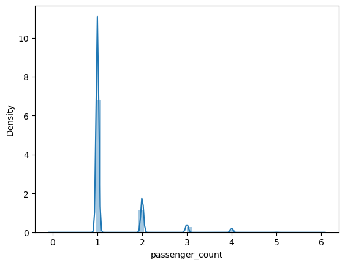

```python
sns.distplot(merged['passenger_count'])
```

```python
fig = px.bar(pax_freq, x="index", y="passenger_count", title="Histogram of Passenger Count Distribution January 2013")
fig.update_xaxes(showgrid=True, ticklabelmode="period", dtick="M1", tickformat="%d\n%Y")
fig.update_layout(bargap=0.1)
fig.show()
```

# Outlier Removal

```python
# #get numeric columns
# numerics = list(merged.select_dtypes(['int64', 'float64']).columns)
# #numerics.append('pickup_datetime')
# #numerics.append('hack_license')
# # create numeric dataframe
# numerics = merged[numerics]
# numerics = pd.DataFrame(numerics)
# #remove outliers
# #numerics = numerics[(np.abs(stats.zscore(numerics)) < 3).all(axis=1)]
# Q1 = numerics.quantile(0.25)
# Q3 = numerics.quantile(0.75)
# IQR = Q3 - Q1
# numerics = numerics[~((numerics < (Q1 - 1.5 * IQR)) |(numerics > (Q3 + 1.5 * IQR))).any(axis=1)]
```

```python
# #get object columns
# objectcols = list(merged.select_dtypes(['object']).columns)
# objectcols.append('pickup_datetime')
# #create dataframe from object columns
# objectdf = merged[objectcols]
# objectdf = pd.DataFrame(objectdf)

#newdf = numerics.join(objectdf)
```

```python
#newdf.to_pickle('/Users/gretastojanovic/Documents/DataScience/Elula_Job_Pres_Prep/newdf.pickle')
```

# Import newdf variable from this point

```python
newdf = '/Users/gretastojanovic/Desktop/DS/data/newdf.pickle'
newdf = pd.read_pickle(newdf)
newdf = pd.DataFrame(newdf)
```

```python
busiest_pickup = newdf.p_nhood.value_counts()
busiest_pickup = pd.DataFrame(busiest_pickup)
busiest_pickup.head(10)
```

|  | p_nhood |
| --- | --- |
| Manhattan | 695120 |
| New York City | 642947 |
| Long Island City | 325054 |
| Weehawken | 181245 |
| Guttenberg | 17989 |
| Inwood | 437 |

```python
b_pickup_10 = busiest_pickup.iloc[0:10, 0:1]
b_pickup_10.T.columns
```

```
Index(['Manhattan', 'New York City', 'Long Island City', 'Weehawken',
       'Guttenberg', 'Inwood'],
      dtype='object')
```

```python
b_pickup_10['nhood'] = b_pickup_10.index
figure = px.pie(b_pickup_10,
             values='p_nhood',
             names='nhood',hole = 0.5)
figure.show()
```

```python
busiest_dropoff = newdf.d_nhood.value_counts()
busiest_dropoff = pd.DataFrame(busiest_dropoff)
busiest_dropoff.head(10)
```

|  | d_nhood |
| --- | --- |
| Manhattan | 724801 |
| New York City | 598186 |
| Long Island City | 335794 |
| Weehawken | 179058 |
| Hoboken | 24077 |
| The Bronx | 748 |
| Bensonhurst | 128 |

```python
b_dropoff_10 = busiest_dropoff.iloc[0:10, 0:1]
b_dropoff_10.T.columns
```

```
Index(['Manhattan', 'New York City', 'Long Island City', 'Weehawken',
       'Hoboken', 'The Bronx', 'Bensonhurst'],
      dtype='object')
```

```python
b_dropoff_10['nhood'] = b_dropoff_10.index
figure = px.pie(b_dropoff_10,
             values='d_nhood',
             names='nhood',hole = 0.5)
figure.show()
```

# Trip Tally

```python
trip_tally = pd.DataFrame(newdf.groupby('p_date', as_index = False)['counter'].count())
fig = px.line(trip_tally, x='p_date', y='counter')
fig.update_xaxes(rangeslider_visible=True)
fig.show()
```

# Trips By Hour of Day

```python
hour_tally = pd.DataFrame(newdf.groupby('p_hour', as_index = False)['counter'].count())
fig = px.bar(hour_tally, x='p_hour', y = 'counter')
fig.show()
```

# Trips By Day of Week

```python
day_of_week = pd.DataFrame(newdf.groupby('p_day_name', as_index = False)['counter'].count())
fig = px.bar(day_of_week, x='p_day_name', y = 'counter')
fig.show()
```

# Busiest Pickup Locations

```python
busiest_pickups = b_pickup_10.T.columns
busiest_pickups
```

```
Index(['Manhattan', 'New York City', 'Long Island City', 'Weehawken',
       'Guttenberg', 'Inwood'],
      dtype='object')
```

```python
bpups = newdf[newdf['p_nhood'].isin(busiest_pickups)]
#bpups = bpups.set_index(['pickup_datetime'])
bpups = pd.DataFrame(bpups.groupby(['p_date', 'p_nhood'], as_index = False)['counter'].sum())
bpups.head()
```

|  | p_date | p_nhood | counter |
| --- | --- | --- | --- |
| 0 | 2013-01-01 | Guttenberg | 437 |
| 1 | 2013-01-01 | Inwood | 25 |
| 2 | 2013-01-01 | Long Island City | 7960 |
| 3 | 2013-01-01 | Manhattan | 13612 |
| 4 | 2013-01-01 | New York City | 13896 |

```python
fig = px.line(bpups, x="p_date", y="counter", color='p_nhood')
fig.show()
```

```python
bpups = newdf[newdf['p_nhood'].isin(busiest_pickups)]
bpups_hours = pd.DataFrame(bpups.groupby(['p_hour', 'p_nhood'], as_index = False)['counter'].sum())
```

```python
fig = px.line(bpups_hours, x="p_hour", y="counter", color='p_nhood')
fig.show()
```

```python
bpups = pd.DataFrame(bpups)
bpups.head()
```

|  | counter | p_hour | rate_code | passenger_count | trip_time_in_secs | trip_distance | fare_amount | surcharge | tip_amount | tolls_amount | ... | payment_type_f | hack_license | p_nhood | p_date | p_day_name | medallion | d_nhood | pickup_datetime | payment_type | pickup_datetime |
| --- | --- | --- | --- | --- | --- | --- | --- | --- | --- | --- | --- | --- | --- | --- | --- | --- | --- | --- | --- | --- | --- |
| 157 | 1 | 9 | 1 | 1 | 864 | 3.5 | 14.5 | 0.0 | 3.0 | 0.0 | ... | 3 | 3A67732A99ABBB120CA502265403AEFA | Manhattan | 2013-01-18 | Friday | 510F91A0265222950F60366022423941 | New York City | 2013-01-18 09:35:38 | CRD | 2013-01-18 09:35:38 |
| 158 | 1 | 11 | 1 | 1 | 136 | 0.3 | 3.5 | 0.0 | 1.0 | 0.0 | ... | 3 | 9D26352E4FBD7E6966BEA23AC341470D | Manhattan | 2013-01-18 | Friday | 5C4AF8B1814695EB3B030C19C0C21673 | Manhattan | 2013-01-18 11:47:37 | CRD | 2013-01-18 11:47:37 |
| 159 | 1 | 21 | 1 | 1 | 1201 | 3.9 | 16.5 | 0.5 | 3.5 | 0.0 | ... | 3 | AFE547B1C02D940CB260AC23B2291E2F | Manhattan | 2013-01-18 | Friday | D572961534554BBF165A036C2918E41C | New York City | 2013-01-18 21:18:35 | CRD | 2013-01-18 21:18:35 |
| 160 | 1 | 9 | 1 | 1 | 233 | 0.5 | 4.5 | 0.0 | 1.0 | 0.0 | ... | 3 | 160485CBBCC26D9D76C437C6C4230E2E | Weehawken | 2013-01-18 | Friday | 49542EE7F0E08DF3D6FB862E4997AF34 | Hoboken | 2013-01-18 09:23:42 | CRD | 2013-01-18 09:23:42 |
| 161 | 1 | 13 | 1 | 1 | 485 | 1.4 | 7.5 | 0.0 | 1.6 | 0.0 | ... | 3 | DF3743182AF0E1555910468BBAF6730A | Manhattan | 2013-01-18 | Friday | 594449F9B1530C900A1FB17B07927BE3 | New York City | 2013-01-18 13:57:23 | CRD | 2013-01-18 13:57:23 |

5 rows × 24 columns

# Busiest Pickup Locations by Date and Hour

```python
f1 = bpups.groupby(['p_date', 'p_hour'], as_index = False)[' fare_amount'].mean()
f1['p_date'] = pd.to_datetime(f1['p_date'], format='%Y-%m-%d')
f1.head()
```

|  | p_date | p_hour | fare_amount |
| --- | --- | --- | --- |
| 0 | 2013-01-01 | 0 | 10.249417 |
| 1 | 2013-01-01 | 1 | 10.423091 |
| 2 | 2013-01-01 | 2 | 10.286364 |
| 3 | 2013-01-01 | 3 | 10.152046 |
| 4 | 2013-01-01 | 4 | 9.784906 |

# Fare Amount by Hour

```python
figure = px.scatter(f1, x=" fare_amount",
                    y="p_hour", size=" fare_amount", color= " fare_amount", trendline="ols")
figure.show()
```

```python
f2 = bpups.groupby(['p_day_name_f', 'p_hour'], as_index = False)[' fare_amount'].mean()

figure = px.scatter(f2, x="p_day_name_f",
                    y=" fare_amount", size=" fare_amount", color= " fare_amount", trendline="ols")
figure.show()
```

```python
f2.head()
```

|  | p_day_name_f | p_hour | fare_amount |
| --- | --- | --- | --- |
| 0 | 0 | 0 | 9.782097 |
| 1 | 0 | 1 | 9.977408 |
| 2 | 0 | 2 | 9.979345 |
| 3 | 0 | 3 | 9.864490 |
| 4 | 0 | 4 | 9.587238 |

# Distribution of Fares

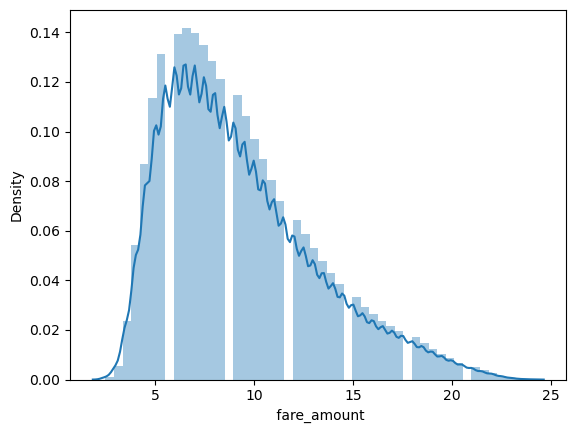

```python
sns.distplot(newdf[' fare_amount'])
```

# Distribution of Tips

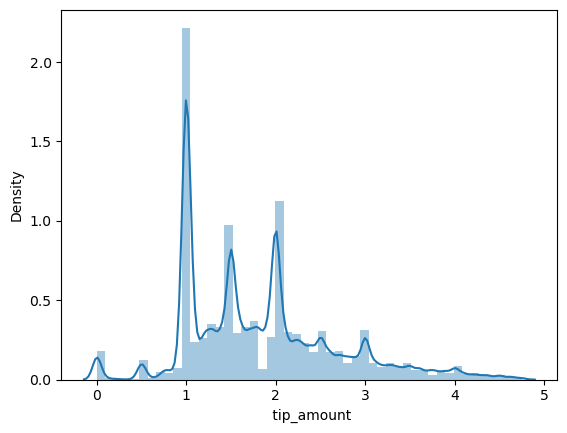

```python
sns.distplot(newdf[' tip_amount'])
```

# Modelling

```python
selection = ['p_hour', 'rate_code', 'passenger_count', 'trip_time_in_secs', 'trip_distance', ' fare_amount',
             ' surcharge', ' tip_amount', ' tolls_amount', 'p_nhood_f', 'd_nhood_f', 'p_day_name_f', ' payment_type_f']
```

```python
#set variable ad for analysis data
ad = newdf[selection]
```

```python
tipped = newdf[' tip_amount'] > 0
```

```python
#add field for whether or not the driver was tipped
newdf['tipped'] = tipped
```

```python
ad['tipped'] = tipped
ad.tipped.value_counts()
```

```
True     1833150
False      29642
Name: tipped, dtype: int64
```

# Correlation Plots

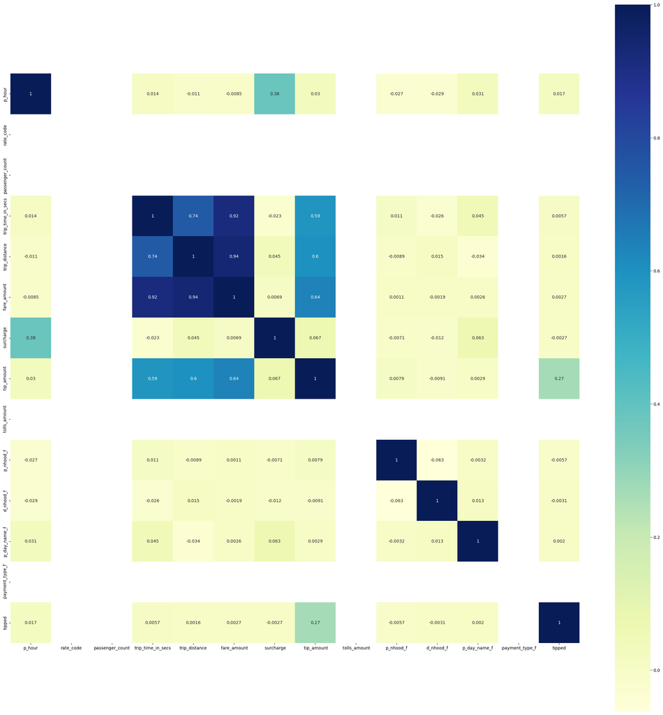

```python
#plot correlation matrix
plt.figure(figsize = (30,30))
corrmat = ad.corr()
sns.heatmap(corrmat, annot = True, square = True, cmap = 'YlGnBu')
plt.show()
```

```python
# show top 10 correlations with fare amount variable
corr = ad.corr()
corr = pd.DataFrame(corr)
fa = pd.DataFrame(corr[' fare_amount'])
fa['abs'] = abs(fa[' fare_amount'].values)
fa.sort_values(by = 'abs', ascending = False).head(10)
```

|  | fare_amount | abs |
| --- | --- | --- |
| fare_amount | 1.000000 | 1.000000 |
| trip_distance | 0.938267 | 0.938267 |
| trip_time_in_secs | 0.916532 | 0.916532 |
| tip_amount | 0.639353 | 0.639353 |
| p_hour | -0.008493 | 0.008493 |
| surcharge | 0.006945 | 0.006945 |
| tipped | 0.002678 | 0.002678 |
| p_day_name_f | 0.002589 | 0.002589 |
| d_nhood_f | -0.001909 | 0.001909 |
| p_nhood_f | 0.001076 | 0.001076 |

```python
# show top 10 correlations with tip amount variable
corr = ad.corr()
corr = pd.DataFrame(corr)
ta = pd.DataFrame(corr[' tip_amount'])
ta['abs'] = abs(ta[' tip_amount'].values)
ta.sort_values(by = 'abs', ascending = False).head(10)
```

|  | tip_amount | abs |
| --- | --- | --- |
| tip_amount | 1.000000 | 1.000000 |
| fare_amount | 0.639353 | 0.639353 |
| trip_distance | 0.600361 | 0.600361 |
| trip_time_in_secs | 0.588936 | 0.588936 |
| tipped | 0.267286 | 0.267286 |
| surcharge | 0.066857 | 0.066857 |
| p_hour | 0.029596 | 0.029596 |
| d_nhood_f | -0.009128 | 0.009128 |
| p_nhood_f | 0.007919 | 0.007919 |
| p_day_name_f | 0.002927 | 0.002927 |

```python
# pairplot for numeric columns
#sns.pairplot(ad, hue='tipped')
#plt.show()
```

## Top 10 best times for tips:

## 9pm, 9am, 5pm, 8pm, 11pm, 8am, 10pm, 7pm, 3pm, 6pm

```python
ad.head()
```

|  | p_hour | rate_code | passenger_count | trip_time_in_secs | trip_distance | fare_amount | surcharge | tip_amount | tolls_amount | p_nhood_f | d_nhood_f | p_day_name_f | payment_type_f | tipped |
| --- | --- | --- | --- | --- | --- | --- | --- | --- | --- | --- | --- | --- | --- | --- |
| 157 | 9 | 1 | 1 | 864 | 3.5 | 14.5 | 0.0 | 3.0 | 0.0 | 0 | 1 | 6 | 3 | True |
| 158 | 11 | 1 | 1 | 136 | 0.3 | 3.5 | 0.0 | 1.0 | 0.0 | 0 | 2 | 6 | 3 | True |
| 159 | 21 | 1 | 1 | 1201 | 3.9 | 16.5 | 0.5 | 3.5 | 0.0 | 0 | 1 | 6 | 3 | True |
| 160 | 9 | 1 | 1 | 233 | 0.5 | 4.5 | 0.0 | 1.0 | 0.0 | 3 | 4 | 6 | 3 | True |
| 161 | 13 | 1 | 1 | 485 | 1.4 | 7.5 | 0.0 | 1.6 | 0.0 | 0 | 1 | 6 | 3 | True |

```python
figure = px.pie(ad,
             values=' tip_amount',
             names='p_hour',hole = 0.5)
figure.show()
```

## Top 10 best times for fares

## 10pm, 9am, 2pm, 9pm, 6pm, 5pm, 8pm, 7pm, noon, 11pm

```python
figure = px.pie(ad,
             values=' fare_amount',
             names='p_hour',hole = 0.5)
figure.show()
```

```python
# #plot distributions
# sns.set(style="dark")
# fig,axs = plt.subplots(3,2, figsize = (15,12))
# sns.histplot(data=ad, x=" fare_amount", kde=True, color="skyblue", ax=axs[0, 0])
# sns.histplot(data=ad, x=" tip_amount", kde=True, color="skyblue", ax=axs[0, 1])
# sns.histplot(data=ad, x="p_hour", kde=True, color="olive", ax=axs[1, 0])
# sns.histplot(data=ad, x="passenger_count", kde=True, color="skyblue", ax=axs[1, 1])
# sns.histplot(data=ad, x=" payment_type_f", kde=True, color="blue", ax=axs[2, 0])
# sns.histplot(data=ad, x="p_day_name_f", kde=True, color="blue", ax=axs[2, 1])
# sns.histplot(data=ad, x="p_nhood_f", kde=True, color="blue", ax=axs[2, 0])

#fig.tight_layout()
```

```python
ad.index = newdf['pickup_datetime']
datamodel = ad[['p_hour', 'rate_code', 'passenger_count', 'trip_time_in_secs', 'trip_distance', ' payment_type_f', ' surcharge', ' tolls_amount', 'p_nhood_f', 'd_nhood_f', 'p_day_name_f', ' fare_amount', ' tip_amount']]
```

```python
from sklearn.preprocessing import StandardScaler
from sklearn.linear_model import LinearRegression
from sklearn.metrics import r2_score
from sklearn.metrics import mean_squared_error
from sklearn.metrics import mean_absolute_error
from sklearn.model_selection import train_test_split
```

```python
scaler = StandardScaler()
scaled = scaler.fit_transform(datamodel)
```

```python
scaled = pd.DataFrame(scaled)
colnames = ['p_hour', 'rate_code', 'passenger_count', 'trip_time_in_secs',
       'trip_distance', ' payment_type_f', ' surcharge', ' tolls_amount',
       'p_nhood_f', 'd_nhood_f', 'p_day_name_f', ' fare_amount',
       ' tip_amount']
scaled.columns = colnames
```

```python
x = scaled[['p_hour', 'rate_code', 'passenger_count', 'trip_time_in_secs',
       'trip_distance', ' payment_type_f', ' surcharge', ' tolls_amount',
       'p_nhood_f', 'd_nhood_f', 'p_day_name_f']]
y = scaled[" fare_amount"]

xtrain, xtest, ytrain, ytest = train_test_split(x, y,
                                                test_size=0.2,
                                                random_state=42)
model = LinearRegression()
ft = model.fit(xtrain, ytrain)
```

```python
y_prediction =  ft.predict(xtest)
y_prediction[:3]
res = pd.DataFrame(ytest)
res['predicted'] = y_prediction
res.head()
```

|  | fare_amount | predicted |
| --- | --- | --- |
| 1217767 | 1.100379 | 1.124252 |
| 187061 | 0.056081 | 0.068919 |
| 73107 | -0.857680 | -0.766854 |
| 538568 | 2.536288 | 2.330501 |
| 1316334 | -0.335531 | -0.317501 |

```python
score=r2_score(ytest,y_prediction)
print('r2 score is ',score)
print('mean_sqrd_error is==',mean_squared_error(ytest,y_prediction))
print('mean_absolute_error==',mean_absolute_error(ytest,y_prediction))
```

```
r2 score is  0.9881103500892618
mean_sqrd_error is== 0.011910348757643237
mean_absolute_error== 0.06950980657025585
```

```python
res = pd.DataFrame(res[[' fare_amount', 'predicted']])
res = res.reset_index()
res.head()
```

|  | index | fare_amount | predicted |
| --- | --- | --- | --- |
| 0 | 1217767 | 1.100379 | 1.124252 |
| 1 | 187061 | 0.056081 | 0.068919 |
| 2 | 73107 | -0.857680 | -0.766854 |
| 3 | 538568 | 2.536288 | 2.330501 |
| 4 | 1316334 | -0.335531 | -0.317501 |

```python
resmelt = pd.melt(res, id_vars=['index'], value_vars=[' fare_amount', 'predicted'])
resmelt.head()
```

|  | index | variable | value |
| --- | --- | --- | --- |
| 0 | 1217767 | fare_amount | 1.100379 |
| 1 | 187061 | fare_amount | 0.056081 |
| 2 | 73107 | fare_amount | -0.857680 |
| 3 | 538568 | fare_amount | 2.536288 |
| 4 | 1316334 | fare_amount | -0.335531 |

```python
x = scaled[['p_hour', 'rate_code', 'passenger_count', 'trip_time_in_secs',
       'trip_distance', ' payment_type_f', ' surcharge', ' tolls_amount',
       'p_nhood_f', 'd_nhood_f', 'p_day_name_f']]
y = scaled[" tip_amount"]

xtrain, xtest, ytrain, ytest = train_test_split(x, y,
                                                test_size=0.2,
                                                random_state=42)
model2 = LinearRegression()
ft2 = model.fit(xtrain, ytrain)

y_prediction =  ft.predict(xtest)
y_prediction[:3]
res2 = pd.DataFrame(ytest)
res2['predicted'] = y_prediction
```

```python
score=r2_score(ytest,y_prediction)
print('r2 score is ',score)
print('mean_sqrd_error is==',mean_squared_error(ytest,y_prediction))
print('mean_absolute_error==',mean_absolute_error(ytest,y_prediction))
```

```
r2 score is  0.4122392145231707
mean_sqrd_error is== 0.5900869133012417
mean_absolute_error== 0.558487524188224
```

```python
res2 = pd.DataFrame(res2[[' tip_amount', 'predicted']])
res2.head()
```

|  | tip_amount | predicted |
| --- | --- | --- |
| 1217767 | 1.363833 | 0.685228 |
| 187061 | 0.208574 | -0.016815 |
| 73107 | 0.324100 | -0.440429 |
| 538568 | -0.369055 | 1.410261 |
| 1316334 | -0.138003 | -0.246594 |

# Taxi Driver Clustering Exercise

```python
import pandas as pd
import numpy as np
import plotly.express as px
import seaborn as sns
import matplotlib.pyplot as plt
from sklearn.cluster import KMeans

from sklearn.neighbors import NearestNeighbors

from sklearn.preprocessing import StandardScaler


from sklearn.metrics import silhouette_score
from sklearn.metrics import adjusted_rand_score

from scipy import stats
from kmodes.kmodes import KModes
```

```python
scaled['hack_license'] = newdf.hack_license
```

```python
scaled.info()
```

```
<class 'pandas.core.frame.DataFrame'>
RangeIndex: 1862792 entries, 0 to 1862791
Data columns (total 14 columns):
 #   Column             Dtype
---  ------             -----
 0   p_hour             float64
 1   rate_code          float64
 2   passenger_count    float64
 3   trip_time_in_secs  float64
 4   trip_distance      float64
 5    payment_type_f    float64
 6    surcharge         float64
 7    tolls_amount      float64
 8   p_nhood_f          float64
 9   d_nhood_f          float64
 10  p_day_name_f       float64
 11   fare_amount       float64
 12   tip_amount        float64
 13  hack_license       object
dtypes: float64(13), object(1)
memory usage: 199.0+ MB
```

```python
scaled2 = scaled[['hack_license', 'trip_time_in_secs', ' fare_amount']]
scaled2.head()
```

|  | hack_license | trip_time_in_secs | fare_amount |
| --- | --- | --- | --- |
| 0 | NaN | 0.907267 | 1.361453 |
| 1 | NaN | -1.465413 | -1.510366 |
| 2 | NaN | 2.005610 | 1.883602 |
| 3 | NaN | -1.149273 | -1.249291 |
| 4 | NaN | -0.327961 | -0.466068 |

```python
scaled2 = scaled2.set_index('hack_license')
```

```python
scaled2.head()
```

| hack_license | trip_time_in_secs | fare_amount |
| --- | --- | --- |
| NaN | 0.907267 | 1.361453 |
| NaN | -1.465413 | -1.510366 |
| NaN | 2.005610 | 1.883602 |
| NaN | -1.149273 | -1.249291 |
| NaN | -0.327961 | -0.466068 |

```python
def plot_elbow_graph(dataset, k_range=range(1, 11)):

    # A list holds the inertia values for each k

    inertia_lst = []

    for k in k_range:

        km_model = KMeans(n_clusters=k, random_state=1)

        km_model.fit(dataset)

        inertia_lst.append(km_model.inertia_)

    plt.figure(figsize=(10,6))

    plt.plot(k_range, inertia_lst)

    plt.xticks(k_range)

    plt.xlabel("Number of Clusters")

    plt.ylabel("Inertia")

    plt.show()

def plot_silhouette_graph(dataset, k_range=range(2, 11)):

    # A list holds the silhouette coefficients for each k

    silhouette_coefficients = []

    for k in k_range:

        km_model = KMeans(n_clusters=k, random_state=1)

        km_model.fit(dataset)

        score = silhouette_score(dataset, km_model.labels_)

        silhouette_coefficients.append(score)

    plt.figure(figsize=(10,6))

    plt.plot(k_range, silhouette_coefficients)

    plt.xticks(k_range)

    plt.xlabel("Number of Clusters")

    plt.ylabel("Silhouette Coefficient")

    plt.show()
```

```python
#plot_elbow_graph(scaled2, k_range=range(2, 20))

#plot_silhouette_graph(scaled2, k_range=range(2, 20))
```

```python
# k means using 6 clusters and k-means++ initialization
model = KMeans(n_clusters = 4, init='k-means++', random_state = 1)
rres = model.fit(scaled2)
datamodel["cluster"] = rres.predict(scaled2)
datamodel["cluster"].value_counts()
```

```
1    622499
3    607467
2    430833
0    201993
Name: cluster, dtype: int64
```

```python
datamodel.head()
```

| pickup_datetime | p_hour | rate_code | passenger_count | trip_time_in_secs | trip_distance | payment_type_f | surcharge | tolls_amount | p_nhood_f | d_nhood_f | p_day_name_f | fare_amount | tip_amount | cluster |
| --- | --- | --- | --- | --- | --- | --- | --- | --- | --- | --- | --- | --- | --- | --- |
| 2013-01-18 09:35:38 | 9 | 1 | 1 | 864 | 3.5 | 3 | 0.0 | 0.0 | 0 | 1 | 6 | 14.5 | 3.0 | 2 |
| 2013-01-18 11:47:37 | 11 | 1 | 1 | 136 | 0.3 | 3 | 0.0 | 0.0 | 0 | 2 | 6 | 3.5 | 1.0 | 3 |
| 2013-01-18 21:18:35 | 21 | 1 | 1 | 1201 | 3.9 | 3 | 0.5 | 0.0 | 0 | 1 | 6 | 16.5 | 3.5 | 0 |
| 2013-01-18 09:23:42 | 9 | 1 | 1 | 233 | 0.5 | 3 | 0.0 | 0.0 | 3 | 4 | 6 | 4.5 | 1.0 | 3 |
| 2013-01-18 13:57:23 | 13 | 1 | 1 | 485 | 1.4 | 3 | 0.0 | 0.0 | 0 | 1 | 6 | 7.5 | 1.6 | 1 |

```python
c0 = datamodel[datamodel['cluster'] == 0]
c0.describe()
```

|  | p_hour | rate_code | passenger_count | trip_time_in_secs | trip_distance | payment_type_f | surcharge | tolls_amount | p_nhood_f | d_nhood_f | p_day_name_f | fare_amount | tip_amount | cluster |
| --- | --- | --- | --- | --- | --- | --- | --- | --- | --- | --- | --- | --- | --- | --- |
| count | 201993.000000 | 201993.0 | 201993.0 | 201993.000000 | 201993.000000 | 201993.0 | 201993.000000 | 201993.0 | 201993.000000 | 201993.000000 | 201993.000000 | 201993.000000 | 201993.000000 | 201993.0 |
| mean | 13.394801 | 1.0 | 1.0 | 1178.382236 | 4.100151 | 3.0 | 0.307441 | 0.0 | 0.999129 | 1.672221 | 3.201378 | 16.880873 | 2.895249 | 0.0 |
| std | 6.133196 | 0.0 | 0.0 | 193.948186 | 1.157121 | 0.0 | 0.374567 | 0.0 | 0.998940 | 0.921154 | 2.104085 | 2.213919 | 1.105607 | 0.0 |
| min | 0.000000 | 1.0 | 1.0 | 351.000000 | 0.000000 | 3.0 | 0.000000 | 0.0 | 0.000000 | 0.000000 | 0.000000 | 6.500000 | 0.000000 | 0.0 |
| 25% | 9.000000 | 1.0 | 1.0 | 1044.000000 | 3.200000 | 3.0 | 0.000000 | 0.0 | 0.000000 | 1.000000 | 1.000000 | 15.000000 | 2.000000 | 0.0 |
| 50% | 14.000000 | 1.0 | 1.0 | 1158.000000 | 4.100000 | 3.0 | 0.000000 | 0.0 | 1.000000 | 2.000000 | 4.000000 | 16.500000 | 3.100000 | 0.0 |
| 75% | 19.000000 | 1.0 | 1.0 | 1300.000000 | 5.000000 | 3.0 | 0.500000 | 0.0 | 1.000000 | 2.000000 | 5.000000 | 18.500000 | 3.750000 | 0.0 |
| max | 23.000000 | 1.0 | 1.0 | 1687.000000 | 6.300000 | 3.0 | 1.000000 | 0.0 | 5.000000 | 6.000000 | 6.000000 | 24.000000 | 4.750000 | 0.0 |

```python
c1 = datamodel[datamodel['cluster'] == 1]
c1.describe()
```

|  | p_hour | rate_code | passenger_count | trip_time_in_secs | trip_distance | payment_type_f | surcharge | tolls_amount | p_nhood_f | d_nhood_f | p_day_name_f | fare_amount | tip_amount | cluster |
| --- | --- | --- | --- | --- | --- | --- | --- | --- | --- | --- | --- | --- | --- | --- |
| count | 622499.000000 | 622499.0 | 622499.0 | 622499.000000 | 622499.000000 | 622499.0 | 622499.000000 | 622499.0 | 622499.000000 | 622499.000000 | 622499.000000 | 622499.000000 | 622499.000000 | 622499.0 |
| mean | 13.517935 | 1.0 | 1.0 | 535.047663 | 1.717641 | 3.0 | 0.317768 | 0.0 | 1.030516 | 1.698748 | 3.088440 | 8.524470 | 1.706184 | 1.0 |
| std | 6.258994 | 0.0 | 0.0 | 89.396269 | 0.557144 | 0.0 | 0.372064 | 0.0 | 1.010135 | 0.929604 | 2.067136 | 1.096159 | 0.588332 | 0.0 |
| min | 0.000000 | 1.0 | 1.0 | 0.000000 | 0.000000 | 3.0 | 0.000000 | 0.0 | 0.000000 | 0.000000 | 0.000000 | 2.500000 | 0.000000 | 1.0 |
| 25% | 9.000000 | 1.0 | 1.0 | 465.000000 | 1.300000 | 3.0 | 0.000000 | 0.0 | 0.000000 | 1.000000 | 1.000000 | 7.500000 | 1.200000 | 1.0 |
| 50% | 14.000000 | 1.0 | 1.0 | 529.000000 | 1.700000 | 3.0 | 0.000000 | 0.0 | 1.000000 | 2.000000 | 3.000000 | 8.500000 | 1.800000 | 1.0 |
| 75% | 19.000000 | 1.0 | 1.0 | 601.000000 | 2.100000 | 3.0 | 0.500000 | 0.0 | 2.000000 | 2.000000 | 5.000000 | 9.500000 | 2.000000 | 1.0 |
| max | 23.000000 | 1.0 | 1.0 | 1272.000000 | 6.300000 | 3.0 | 1.000000 | 0.0 | 5.000000 | 6.000000 | 6.000000 | 18.000000 | 4.750000 | 1.0 |

```python
c2 = datamodel[datamodel['cluster'] == 2]
c2.describe()
```

|  | p_hour | rate_code | passenger_count | trip_time_in_secs | trip_distance | payment_type_f | surcharge | tolls_amount | p_nhood_f | d_nhood_f | p_day_name_f | fare_amount | tip_amount | cluster |
| --- | --- | --- | --- | --- | --- | --- | --- | --- | --- | --- | --- | --- | --- | --- |
| count | 430833.000000 | 430833.0 | 430833.0 | 430833.000000 | 430833.000000 | 430833.0 | 430833.000000 | 430833.0 | 430833.000000 | 430833.000000 | 430833.000000 | 430833.000000 | 430833.000000 | 430833.0 |
| mean | 13.475549 | 1.0 | 1.0 | 812.452612 | 2.746892 | 3.0 | 0.316544 | 0.0 | 1.056481 | 1.682691 | 3.115272 | 12.095246 | 2.255226 | 2.0 |
| std | 6.282315 | 0.0 | 0.0 | 122.619442 | 0.886695 | 0.0 | 0.371010 | 0.0 | 1.024285 | 0.929898 | 2.080517 | 1.585378 | 0.842444 | 0.0 |
| min | 0.000000 | 1.0 | 1.0 | 0.000000 | 0.000000 | 3.0 | 0.000000 | 0.0 | 0.000000 | 0.000000 | 0.000000 | 2.500000 | 0.000000 | 2.0 |
| 25% | 9.000000 | 1.0 | 1.0 | 726.000000 | 2.100000 | 3.0 | 0.000000 | 0.0 | 0.000000 | 1.000000 | 1.000000 | 11.000000 | 1.500000 | 2.0 |
| 50% | 14.000000 | 1.0 | 1.0 | 802.000000 | 2.700000 | 3.0 | 0.000000 | 0.0 | 1.000000 | 2.000000 | 3.000000 | 12.000000 | 2.400000 | 2.0 |
| 75% | 19.000000 | 1.0 | 1.0 | 894.000000 | 3.300000 | 3.0 | 0.500000 | 0.0 | 2.000000 | 2.000000 | 5.000000 | 13.000000 | 2.800000 | 2.0 |
| max | 23.000000 | 1.0 | 1.0 | 1685.000000 | 6.300000 | 3.0 | 1.000000 | 0.0 | 5.000000 | 6.000000 | 6.000000 | 23.500000 | 4.750000 | 2.0 |

```python
c2.head()
```

| pickup_datetime | p_hour | rate_code | passenger_count | trip_time_in_secs | trip_distance | payment_type_f | surcharge | tolls_amount | p_nhood_f | d_nhood_f | p_day_name_f | fare_amount | tip_amount | cluster |
| --- | --- | --- | --- | --- | --- | --- | --- | --- | --- | --- | --- | --- | --- | --- |
| 2013-01-18 09:35:38 | 9 | 1 | 1 | 864 | 3.5 | 3 | 0.0 | 0.0 | 0 | 1 | 6 | 14.5 | 3.00 | 2 |
| 2013-01-18 20:33:06 | 20 | 1 | 1 | 863 | 1.8 | 3 | 0.5 | 0.0 | 1 | 1 | 6 | 11.0 | 2.22 | 2 |
| 2013-01-18 13:39:15 | 13 | 1 | 1 | 922 | 2.0 | 3 | 0.0 | 0.0 | 1 | 1 | 6 | 11.5 | 2.40 | 2 |
| 2013-01-18 23:00:15 | 23 | 1 | 1 | 648 | 3.0 | 3 | 0.5 | 0.0 | 2 | 2 | 6 | 11.5 | 2.50 | 2 |
| 2013-01-18 18:28:38 | 18 | 1 | 1 | 915 | 3.3 | 3 | 1.0 | 0.0 | 2 | 2 | 6 | 13.0 | 4.35 | 2 |

```python
c3 = datamodel[datamodel['cluster'] == 3]
c3.describe()
```

|  | p_hour | rate_code | passenger_count | trip_time_in_secs | trip_distance | payment_type_f | surcharge | tolls_amount | p_nhood_f | d_nhood_f | p_day_name_f | fare_amount | tip_amount | cluster |
| --- | --- | --- | --- | --- | --- | --- | --- | --- | --- | --- | --- | --- | --- | --- |
| count | 607467.000000 | 607467.0 | 607467.0 | 607467.000000 | 607467.000000 | 607467.0 | 607467.000000 | 607467.0 | 607467.000000 | 607467.000000 | 607467.000000 | 607467.000000 | 607467.000000 | 607467.0 |
| mean | 13.397445 | 1.0 | 1.0 | 279.485080 | 0.923330 | 3.0 | 0.318044 | 0.0 | 1.008206 | 1.705082 | 3.043777 | 5.546075 | 1.268753 | 3.0 |
| std | 6.340839 | 0.0 | 0.0 | 87.512325 | 0.362012 | 0.0 | 0.369332 | 0.0 | 1.012946 | 0.906347 | 2.055070 | 0.993617 | 0.444085 | 0.0 |
| min | 0.000000 | 1.0 | 1.0 | 0.000000 | 0.000000 | 3.0 | 0.000000 | 0.0 | 0.000000 | 0.000000 | 0.000000 | 2.500000 | 0.000000 | 3.0 |
| 25% | 9.000000 | 1.0 | 1.0 | 216.000000 | 0.700000 | 3.0 | 0.000000 | 0.0 | 0.000000 | 1.000000 | 1.000000 | 5.000000 | 1.000000 | 3.0 |
| 50% | 14.000000 | 1.0 | 1.0 | 287.000000 | 0.900000 | 3.0 | 0.000000 | 0.0 | 1.000000 | 2.000000 | 3.000000 | 5.500000 | 1.200000 | 3.0 |
| 75% | 19.000000 | 1.0 | 1.0 | 349.000000 | 1.100000 | 3.0 | 0.500000 | 0.0 | 2.000000 | 2.000000 | 5.000000 | 6.500000 | 1.500000 | 3.0 |
| max | 23.000000 | 1.0 | 1.0 | 721.000000 | 6.300000 | 3.0 | 1.000000 | 0.0 | 5.000000 | 6.000000 | 6.000000 | 12.000000 | 4.750000 | 3.0 |